# Отчёт по лабораторной работе №3

Работа с Markdown

Автор

принадлежность

Терентеевская Светлана Александровна, Student

Российский университет дружбы народов

Дата публикации

2026-03-07

# Информация

## Докладчик

- Терентеевская Светлана Александровна
- Группа НКАбд-05-25, студент бакалавра
- Российский университет дружбы народов им. П. Лумумбы
- 1032253498@rudn.ru
- https://github.com/SvetlanaTerenteevskaya

# Вводная часть

## Цель работы

Научиться оформлять отчёты с помощью легковесного языка разметки Markdown.

## Задание

Сделать отчёт по предыдущей лабораторной работе в формате Markdown.

## Теоретическое введение

Markdown — это облегчённый язык разметки, предназначенный для оформления текстовых документов с простым синтаксисом, который легко конвертируется в другие форматы, такие как HTML, PDF или DOCX. Основные элементы форматирования включают:

- **Заголовки** — создаются с помощью символа # (например, `# Заголовок 1`, `## Заголовок 2`);
- **Выделение текста** — полужирное начертание (`**текст**`) и курсив (`*текст*`);
- **Списки** — маркированные (с помощью `*`, `+` или `-`) и нумерованные (с помощью цифр с точкой);
- **Блоки цитирования** — обозначаются символом `>`;
- **Ссылки** — формат `[текст ссылки](адрес)`;
- **Вставка кода** — ограждённые блоки с указанием языка (`` ```language ``);
- **Изображения** — `![подпись](путь/к/файлу.png)`;
- **Формулы** — поддерживаются LaTeX-синтаксис внутри `$$` или `\(...\)`.

Для обработки файлов в формате Markdown используется инструмент **Pandoc**, который позволяет преобразовывать `.md` файлы в `.pdf`, `.docx` и другие форматы. При необходимости для автоматизации процесса компиляции применяется **Makefile**.

# Выполнение лабораторной работы

## Лабораторная работа

Я изменила текст шаблона для лабораторной работы и скомпилировала его с помощью команды make (рис. 2).

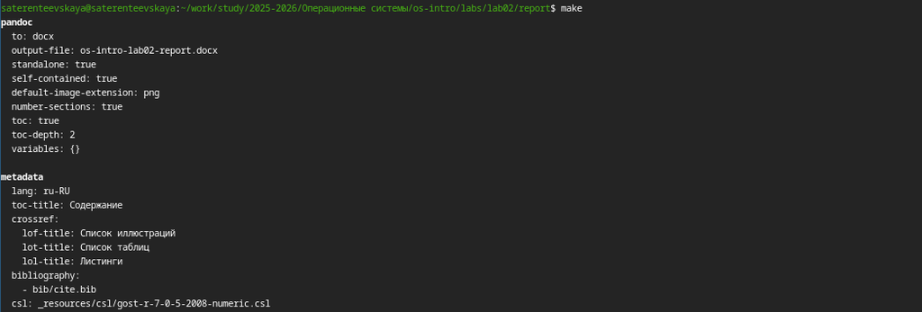

Рисунок 2: Компиляция файла

После компиляции проверила как выклядят файлы (рис. 3).

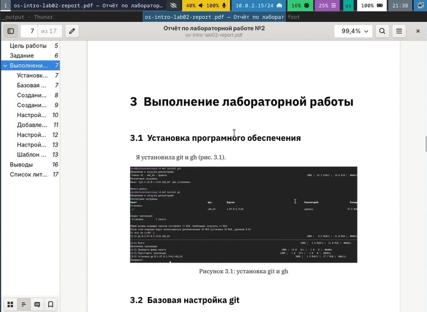

Рисунок 3: Проверка результатов компиляции

# Выводы

В процессе выполнения лабораторной работы я научилась оформлять отчёты с помощью легковесного языка разметки Markdown.

# Список литературы

[ТУИС](https://esystem.rudn.ru/)

[Методичка к лабораторной работе №3](https://esystem.rudn.ru/mod/resource/view.php?id=1358185)